# Group No.4 Assignment 1 Company Reputation Poll

Athbah Alrugibah, Alyazid Alhumaydani, Dhawi Almajnouni, Hassan AlTamimi, Mariam Busaleh

2022-10-13

## 1.Introduction

The Axios-Harris Poll 100 is a trusted raking of the reputation of the companies most on the minds of Americans using a framework Harris has used since 1999. It is based on a survey of 33,096 Americans in a nationally representative sample . The two-step process starts fresh each year by surveying the public’s top-of-mind awareness of companies that either excel or falter in society. These 100 “most visible companies” are then rated by a second group of Americans across the seven key dimensions of reputation to determine the ranking.If a company is not on the list, it did not reach a critical level of visibility to be measured

http://theharrispoll.com/partners/media/axios-harrispoll-100/

## 2.Dataset

**• Title:** 2022 Corporate Reputation and poll Rankings

**• Year:** 2022

**• Source:** Thomas Mock (2022). Tidy Tuesday: A weekly data project aimed at the R ecosystem. https://github.com/rfordatascience/tidytuesday.

**• Purpose of Dataset:** A great dataset for beginners who is learning to work in data analysis and visualization.

**• Content:** Reputation:company,industry,name,score,rank; poll: company, industry, 2022_rank, 2022_rq,change,year,rank rq

**• Structure:** Mainly consist of integers, floating point values also string

**• Summary:** This dataset describes attributes of the Reputation and poll of Companies so the dataset can be make used to propose exploratory data analysis.

## 3.Organization

### 3.1 Checking for missing values

After missing values checking, we found that the poll dataset has 333 NA’s values and the reputation dataset has no NA’s values.

```
## [1] 333
```

```
## [1] 0
```

```
##    company   industry X2022_rank   X2022_rq     change       year       rank
##          0          0          0          0         95          1        153
##         rq
##         84
```

### 3.2 Organizing the datasets

We’ve decided to find the average score of all reputation attributes and the reputation quotient (RQ) for each company and add them both into one data set for cleaner and easier exploration. The NA’s values have been found in four variables which are “change, year, rank, and rq”. Those variables’s values are important for the study and we drop them to get accurate result.

Reputation Attributes Score -> Average Reputation

Reputation Quotient -> Average Reputation Quotient

Merge Both Averages

## 4.EDA

```
##  [1] "Industrial"         "Retail"             "Ecommerce"
##  [4] "Financial Services" "Tech"               "Telecom"
##  [7] "Other"              "Healthcare"         "Energy"
## [10] "Food & Beverage"    "Media"              "Airline"
## [13] "Food Delivery"      "Logistics"          "Automotive"
## [16] "Pharma"             "Consumer Goods"     "Insurance"
## [19] "Groceries"
```

```
## Rows: 97
## Columns: 4
## Groups: company [97]
## $ company   <chr> "3M Company", "Adidas", "Amazon.com", "American Express", "A…
## $ industry  <chr> "Industrial", "Retail", "Ecommerce", "Financial Services", "…
## $ rq_avg    <dbl> 79.94800, 76.71500, 82.63800, 74.35400, 78.60600, 68.62600, …
## $ score_avg <dbl> 77.82857, 78.30143, 80.54173, 77.04429, 78.71143, 72.34286, …
```

```
##    company            industry             rq_avg        score_avg
##  Length:97          Length:97          Min.   :54.86   Min.   :54.41
##  Class :character   Class :character   1st Qu.:70.67   1st Qu.:71.91
##  Mode  :character   Mode  :character   Median :73.85   Median :76.31
##                                        Mean   :73.33   Mean   :74.86
##                                        3rd Qu.:77.94   3rd Qu.:78.76
##                                        Max.   :82.64   Max.   :82.54
```

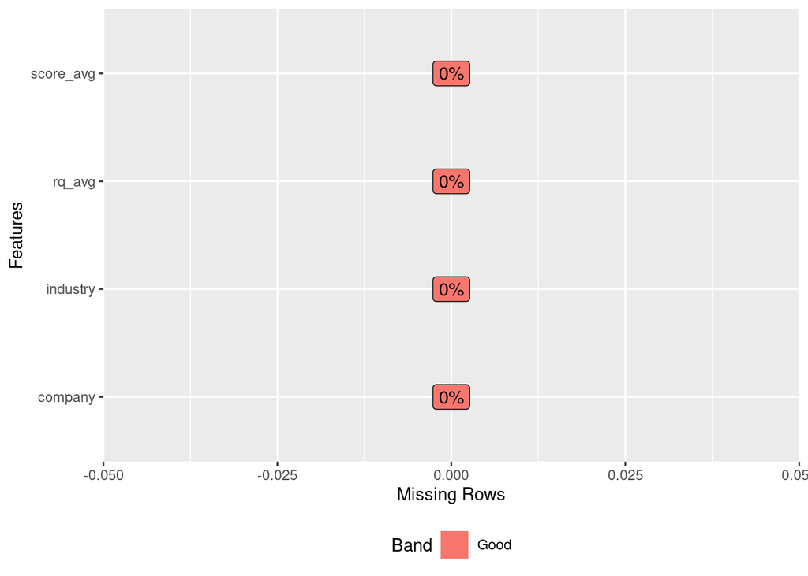

Table: Data summary

| Name | total |
| --- | --- |
| Number of rows | 97 |
| Number of columns | 4 |
| _______________________ |  |
| Column type frequency: |  |
| character | 1 |
| numeric | 2 |
| ________________________ |  |
| Group variables | company |

**Variable type: character**

[output not shown]

[output cut: 67 more lines]

**Variable type: numeric**

[output not shown]

[output cut: 164 more lines]

## Plot

**Average Reputation Score vs. Reputation Quotient (RQ)**

With a correlation coefficient of 0.89. We can say Reputation Quotient score is a good representation for a company’s reputation”)

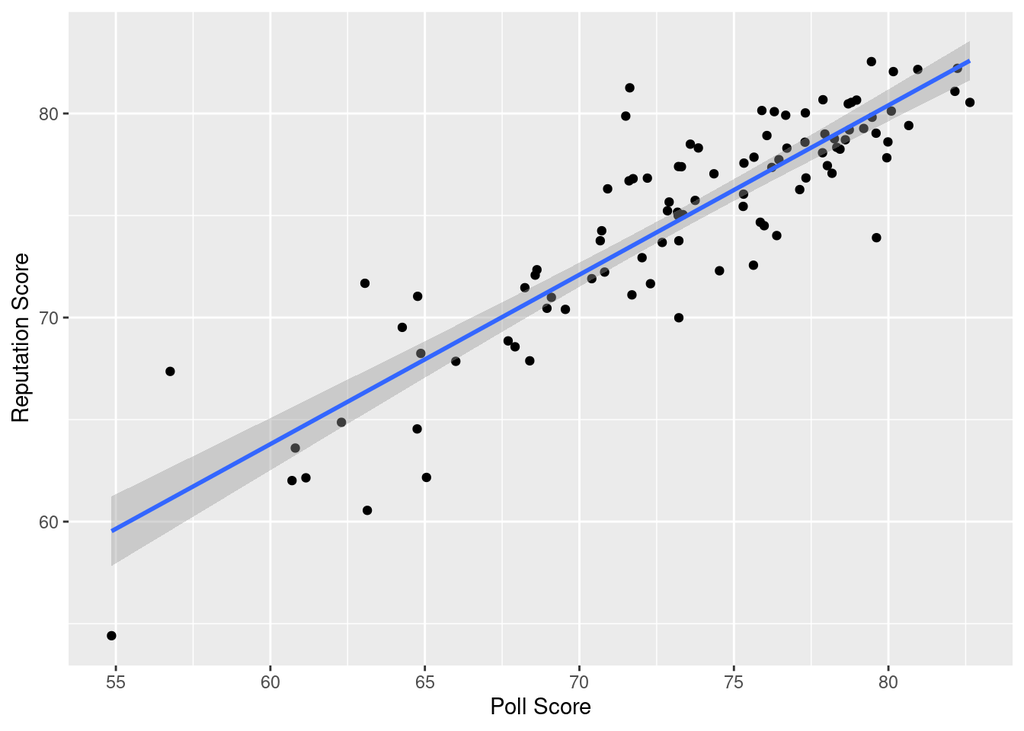

Average Reputation Quotient of each Industry

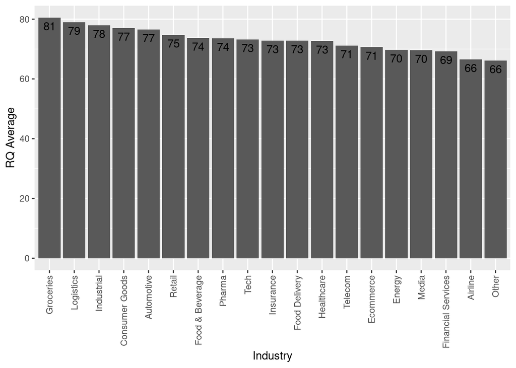

## 5. Hypothesis

**Our current hypothesis is:**

• The grocery industry have a significantly better reputation than other industries.

• The Airline industry have a significantly worse reputation than other industries.

## 6. additional resources

A study conducted by Insiders and titled “Americans say they trust major companies like Clorox, Amazon, and Publix to keep the country going during the pandemic more than they trust the government” followed the same methodology as our study.

It aimed to understand the public view of companies and companies could efficiently play the role of federal government during pandemics. It included two groups as well as Phase I and Phase II, similar to our study. It included 34,000 American adults.

In phase I, survered group were asked about if certain companies performed better than the federal goverment during Covid-19 pandemic.

In phase II, companies that were selected were ranked based of the best performance.

The study concluded that companies performed better than the federal government and supplied groceries to American people during the pandemic. In fact, 76% of surveyed believed the companies were more reliable than the federal government pertaining to securing groceres.

Top companies ranked one to five included the following: - 1 The Clorox Company ranked in terms of ethics, products and services.

The Hershey Company, Amazon, Publix, and General Milles were ranked the top 5 companies in the list.

Companies such as Procter & Gamble, Marker of Charmin, Bounty , and other hosehold essentials ranked 8 in the list.

Reference: https://www.businessinsider.com/clorox-amazon-publix-more-trusted-government-2020-7